# Spooky Author Identification

John Tyson III

November 19, 2017

# Spooky Author Identification

```r
library(tidytext)
library(tidyverse)
library(glue)
library(glmnet)
library(cleanNLP)
```

```r
library(ggplot2)
library(tokenizers)
library(stringi)
library(methods)
library(readr)
library(dplyr)
library(smodels)
library(keras)
library(fasttextM)
```

```r
test <- read_csv("C:/Users/John/Documents/!Senior/Stat Learning/Final Project/test.csv")
train <- read_csv("C:/Users/John/Documents/!Senior/Stat Learning/Final Project/train.csv")
```

## Examining the dataset

### Frequency of each word by author

The Kaggle competition provided me with a dataset with only three columns, the id, the text, and which author wrote the given sentence. Luckily, this format was very similar to some of the datasets we saw in our labs for class. The first step when encountering a new dataset is to figure out some of its nuances. So I created function which split the words up and counted them by author.

```r
### Split data

# split the data by author
byAuthor <- group_by(train, author)

### Calcuate how often each author uses each word

freqByAuthor <-  train %>%
    group_by(author) %>% # group by author
    select(text) %>% # grab only the Sentence column
    mutate(text = as.character(text)) %>% # convert them to characters
    unnest_tokens(words, text) %>% # tokenize
    count(words) %>% # frequency by token (by author)
    bind_tf_idf(words, author, n) # normalized frequency
```

Here are some example outputs.

```r
### Look at how often each writer uses specific words

# see how often each author says "blood"
print(freqByAuthor[freqByAuthor$words == "blood",])
```

```
## # A tibble: 3 x 6
## # Groups:   author [3]
##   author words     n           tf   idf tf_idf
##    <chr> <chr> <int>        <dbl> <dbl>  <dbl>
## 1    EAP blood    34 0.0001692763     0      0
## 2    HPL blood    40 0.0002559787     0      0
## 3    MWS blood    43 0.0002595051     0      0
```

```r
# see how often each author says "scream"
print(freqByAuthor[freqByAuthor$words == "scream",])
```

```
## # A tibble: 3 x 6
## # Groups:   author [3]
##   author  words     n           tf   idf tf_idf
##    <chr>  <chr> <int>        <dbl> <dbl>  <dbl>
## 1    EAP scream     4 1.991486e-05     0      0
## 2    HPL scream    16 1.023915e-04     0      0
## 3    MWS scream     5 3.017502e-05     0      0
```

```r
# see how often each author says "fear"
print(freqByAuthor[freqByAuthor$words == "fear",])
```

```
## # A tibble: 3 x 6
## # Groups:   author [3]
##   author words     n           tf   idf tf_idf
##    <chr> <chr> <int>        <dbl> <dbl>  <dbl>
## 1    EAP  fear    24 0.0001194892     0      0
## 2    HPL  fear    99 0.0006335473     0      0
## 3    MWS  fear   117 0.0007060954     0      0
```

### Formatting the datasets for prediction

Due to the format in which I recieved the ‘train’ and ‘test’ datasets I needed to do some preliminary formatting before I started to make predictions off of the data. First I created training and validation subsets in the ‘train’ dataset. I then created another column for a numeric representation of the authors and tokenized the text in both the ‘train’ and ‘test’ datasets.

```r
train$train_id <- sample(c("train", "valid"), nrow(train), replace = TRUE,
                        prob = c(0.7, 0.3))
train$author2 <- NA
test$author2 <- NA

train$author2 <- as.numeric(factor(train$author)) - 1
```

```r
token_list_train <- tokenize_words(train$text)
token_df_train <- term_list_to_df(token_list_train)

X <- term_df_to_matrix(token_df_train, min_df = 0.05, max_df = 1,
                       scale = FALSE)

y <- train$author2



X_train <- X[train$train_id == "train",]
X_valid <- X[train$train_id == "valid",]
y_train <- y[train$train_id == "train"]
y_valid <- y[train$train_id == "valid"]
```

```r
token_list_test <- tokenize_words(test$text)
token_df_test <- term_list_to_df(token_list_test)

X_test <- term_df_to_matrix(token_df_train, min_df = 0.05, max_df = 1,
                       scale = FALSE)

test$author <- ''
y_test <- train$author2
```

## Modeling

In order to create the best prediciton I experimented with a variety of methods and parameters to ensure I was capturing as many non-linearities in the data as possible.

### Elastic Net

I started with an elastic net because it was relatively quick to set up and easy to fit which gave me a relatively predictive baseline model to improve upon. The elastic net produced a decent prediction of 56% which is far better than random guessing which would have only achieved 33%. However, there is obvious room for improvment on the elastic net.

```r
  model <- cv.glmnet(X_train, y_train, family = "multinomial")
```

```r
pred <- predict(model, newx = X, type = "class", s = model$lambda.min)
tapply(pred == train$author2,
       train$train_id, mean)
```

```
##     train     valid
## 0.5591257 0.5686710
```

### RNN

The next model I considered was a RNN. In order to apply the RNN I had to pad the text and do some more formatting techniques in order for the data to be compatible with the RNN. The after I had built the models below I came back and altered some of the formatting parameters to improve my models. The main formatting parameter I changed was the length of the text, and therefore the amount of padding needed before some of the text. I initally started with 20, however, after some testing I found that a length of 30 was optimal.

```r
train2 <- train[stri_length(train$text) > 30,]
words <- tokenize_words(train2$text)
vocab <- top_n(count(data_frame(word = unlist(words)), word),
                n = 5000)$word
id <- lapply(words, function(v) match(v, vocab))
id <- lapply(id, function(v) v[!is.na(v)])
id <- lapply(id, function(v) {if (length(v) < 2) v <- c(1,2); return(v) })
X2 <- pad_sequences(id, maxlen = 30)
y2 <- train2$author2

X_train2 <- X2[train2$train_id == "train",]
X_valid2 <- X2[train2$train_id == "valid",]
y_train2 <- to_categorical(y2[train2$train_id == "train"], num_classes = 3)
y_valid2 <- to_categorical(y2[train2$train_id == "valid"], num_classes = 3)
```

```r
test2 <- test[stri_length(test$text) > 30,]
words_test <- tokenize_words(test2$text)
vocab_test <- top_n(count(data_frame(word = unlist(words_test)), word),
                n = 5000)$word
id2 <- lapply(words_test, function(v2) match(v2, vocab_test))
id2 <- lapply(id2, function(v2) v2[!is.na(v2)])
id2 <- lapply(id2, function(v2) {if (length(v2) < 2) v2 <- c(1,2); return(v2) })
X2_test <- pad_sequences(id2, maxlen = 30)
y2_test <-  to_categorical(test2$author2, num_classes = 3)
```

When creating the RNN model I relied heavily on the artistic aspect of tuning the model. Therefore I spent a lot of time playing with the unit size and drouput rate to produce the most predictive model. I finally settled on 128 units, 0.05 dropout and recurrent dropout over 12 epochs based on the predictions generated. This produced a prediction rate of 70%.

```r
model_RNN <- keras_model_sequential()
model_RNN %>%
  layer_embedding(input_dim = length(vocab) + 1,
                  output_dim = 3,
                  input_length = ncol(X_train2)) %>%
  layer_simple_rnn(units = 128,
                   dropout = 0.05,
                   recurrent_dropout = 0.05,
                   return_sequences = FALSE) %>%
  layer_dense(units = 3, activation = 'softmax')
```

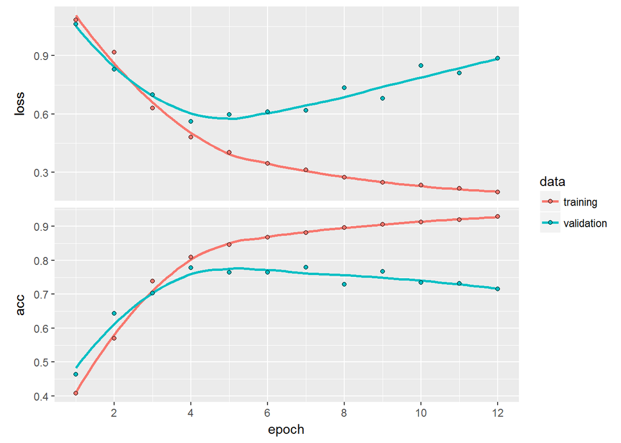

```r
model_RNN %>% compile(loss = 'categorical_crossentropy',
                  optimizer = 'adam',
                  metrics = c('accuracy'))

history <- model_RNN %>% fit(X_train2, y_train2,
              batch_size = 32,
              epochs = 12,
              validation_data = list(X_valid2, y_valid2))
plot(history)
```

```r
train2$y_pred_rnn <- predict_classes(model_RNN, X2)
tapply(train2$author2 == train2$y_pred_rnn, train2$train_id, mean)
```

```
##     train     valid
## 0.9292884 0.7152143
```

### Transfer Learning using fasttextM and LSTM

My final model I will be presenting today is my model using Dr. Arnold’s fasttextM package for transfer learning while using a LSTM neural network.

```r
library(fasttextM)
ft_download_model("en")
ft_load_model("en")
```

Before I can run the model I need to setup some basic word embedings using the fasttextM libary.

```r
ft_load_model("en")
X_words <- matrix(c("", vocab)[X2+1], nrow = nrow(X2))
X_embed <- ft_embed(as.vector(X_words), lang = "en")
X_embed[is.na(X_embed)] <- 0
X_embed <- array(X_embed, dim = c(nrow(X_words), ncol(X_words), 100))
X_embed[1:2,,1]
```

```
##          [,1]     [,2]    [,3]     [,4]     [,5]    [,6]      [,7]
## [1,] 0.048804 -0.12686 0.15532 -0.10668 -0.40083 0.14712 -0.044612
## [2,] 0.000000  0.00000 0.00000  0.00000  0.00000 0.00000  0.000000
##           [,8]    [,9]     [,10]     [,11]    [,12]     [,13]   [,14]
## [1,] -0.099943 0.13521 -0.031533 -0.091653 -0.21341 -0.065334 -0.4228
## [2,]  0.000000 0.00000  0.000000  0.000000  0.00000  0.000000  0.0000
##          [,15]    [,16]   [,17]     [,18]     [,19]    [,20]     [,21]
## [1,] -0.037654 -0.40083 0.14585  0.033539 -0.099526 -0.17497 -0.119550
## [2,]  0.000000  0.00000 0.00000 -0.336600 -0.328940 -0.24221  0.083316
##          [,22]     [,23]    [,24]     [,25]    [,26]     [,27]    [,28]
## [1,]  0.048804 -0.065334 -0.17057 -0.138760 -0.10081 -0.032691 0.039832
## [2,] -0.213410 -0.230370 -0.23983 -0.065334  0.14712 -0.250260 0.115590
##          [,29]     [,30]
## [1,] -0.065334  0.053708
## [2,]  0.007366 -0.441790
```

```r
model_tf <- keras_model_sequential()
model_tf %>%
  layer_lstm(units = 128,
             dropout = 0.05,
             recurrent_dropout = 0.05,
             return_sequences = FALSE,
             input_shape = dim(X_embed)[-1]) %>%
  layer_dense(units = 3, activation = 'softmax')
model_tf
```

```
## Model
## ___________________________________________________________________________
## Layer (type)                     Output Shape                  Param #
## ===========================================================================
## lstm_1 (LSTM)                    (None, 128)                   117248
## ___________________________________________________________________________
## dense_2 (Dense)                  (None, 3)                     387
## ===========================================================================
## Total params: 117,635
## Trainable params: 117,635
## Non-trainable params: 0
## ___________________________________________________________________________
```

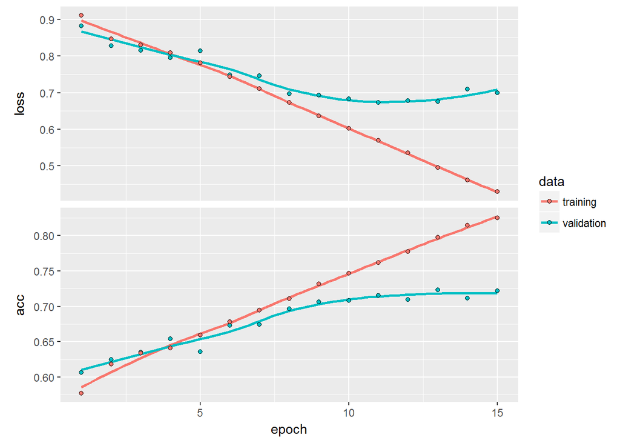

```r
model_tf %>% compile(loss = 'categorical_crossentropy',
                  optimizer = 'adam',
                  metrics = c('accuracy'))

X_train3 <- X_embed[train2$train_id == "train", ,]
X_valid3 <- X_embed[train2$train_id == "valid", ,]
y_train3 <- to_categorical(y2[train2$train_id == "train"], num_classes = 3)
y_valid3 <- to_categorical(y2[train2$train_id == "valid"], num_classes = 3)

history <- model_tf %>% fit(X_train3, y_train3,
              batch_size = 32,
              epochs = 15,
              validation_data = list(X_valid3, y_valid3))
plot(history)
```

```r
y_pred_tf <- predict_classes(model_tf, X_embed)
tapply(y2 == y_pred_tf, train2$train_id, mean)
```

```
##     train     valid
## 0.8817978 0.7222417
```